# Model Selection and Comparison

JVWCD Capstone Group

4/14/2022

# Setup

## Packages

```r
list.of.packages <- c("tidyverse",
                      "lubridate",
                      "chron",
                      "knitr",
                      "corrplot",
                      "caret",
                      "scales",
                      "gridExtra",
                      "useful",
                      "ISOweek",
                      "kableExtra",
                      "matrixStats",
                      "rminer",
                      "mltools",
                      "zoo",
                      "RWeka",
                      "kernlab",
                      "forecast")
new.packages <- list.of.packages[!(list.of.packages %in% installed.packages()[,"Package"])]
if(length(new.packages)) install.packages(new.packages)

library(tidyverse)
library(lubridate)
library(chron)
library(knitr)
library(corrplot)
library(caret)
library(scales)
library(gridExtra)
library(useful)
library(ISOweek)
library(kableExtra)
library(matrixStats)
library(rminer)
library(mltools)
library(zoo)
library(RWeka)
library(kernlab)
library(forecast)

MLP <- make_Weka_classifier("weka/classifiers/functions/MultilayerPerceptron")

# R2
rsq <- function (x, y) cor(x, y) ^ 2
# Performance Metrics
metrics_list = c("R2","MAE","MAPE","RMSE")
```

## Read CSV files and pre process

```r
wa <- read.csv("new_weather_slc_airport.csv")%>%
  mutate(season = ifelse(CalendarMonth %in% c('3','4','5'), 'Spring',
                         ifelse(CalendarMonth %in% c('6','7','8'), 'Summer',
                                ifelse(CalendarMonth %in% c('9','10','11'), 'Fall',
                                       ifelse(CalendarMonth %in% c('12','1','2'), 'Winter','0')))),
         #RainDays = factor(RainDays),
         date = as.Date(WeatherDate,format="%m/%d/%Y"),
         RainDays = ifelse(Precipitation < 0.05, 0 , RainDays),
         Precipitation = ifelse(Precipitation < 0.05, 0 , Precipitation))%>%
  filter(CalendarYear>=2020)


sd <- read.csv("new_daily_demand.csv")%>%
  rename('avg_demand_cfs' = 'Avg.Daily.Demand..cfs.',
         'avg_demand_af' = 'Avg.Daily.Demand..af.',
         'avg_demand_mgd' = 'Avg.Daily.Demand..mgd.',
         'max_demand_cfs' = 'Max.Daily.Demand..cfs.',
         'max_demand_af' = 'Max.Daily.Demand..af.',
         'max_demand_mgd' = 'Max.Daily.Demand..mgd.',
         'min_demand_cfs' = 'Min.Daily.Demand..cfs.',
         'min_demand_af' = 'Min.Daily.Demand..af.',
         'min_demand_mgd' = 'Min.Daily.Demand..mgd.')%>%#Clifton said this is a min
  mutate(date = as.Date(ReadDate,format="%m/%d/%Y"))


wd <- merge(wa,sd,by="date")


mgd_avg <- wd%>%
  select(-avg_demand_cfs,
         -avg_demand_af,
         #-avg_demand_mgd, ## Target Variable
         -max_demand_cfs,
         -max_demand_af,
         -max_demand_mgd,
         -min_demand_cfs,
         -min_demand_af,
         -min_demand_mgd)%>%
  select(-WeatherDate,-ReadDate)


rainwk <- mgd_avg%>%
  mutate(Week_no = format(date, "%U"))%>%
  group_by(Week_no)%>%
  summarize(RainWeek = as.factor(ifelse(sum(RainDays)>0,1,0)))

mgd_avg <- mgd_avg %>%
  mutate(Week_no = as.factor(format(date, "%U")),
         RainDays = as.factor(RainDays),
         season = as.factor(season))

mgd_avg <- dplyr::left_join(mgd_avg,rainwk,by="Week_no")

mgd_avg <- mgd_avg%>% select(-Week_no)

# Rollmean 9 Day Average Calculations
Avg4 <- mgd_avg %>%
  mutate(TempMean4Day = rollmean(TemperatureMean, k = 9, fill = mean(TemperatureMean)),
         Precip4Day = rollmean(Precipitation, k = 9, fill = mean(Precipitation)),
         SnowDepth4Day = rollmean(SnowDepth, k = 9, fill = mean(SnowDepth)))%>%
  select(-Precipitation, -TemperatureMean, -SnowDepth)
```

## Data After Pre Processing

```r
summary(Avg4)
```

```
##       date             CalendarYear  CalendarMonth     CalendarDay
##  Min.   :2020-01-01   Min.   :2020   Min.   : 1.000   Min.   : 1.00
##  1st Qu.:2020-07-25   1st Qu.:2020   1st Qu.: 3.000   1st Qu.: 8.00
##  Median :2021-02-15   Median :2021   Median : 6.000   Median :16.00
##  Mean   :2021-02-15   Mean   :2021   Mean   : 5.993   Mean   :15.61
##  3rd Qu.:2021-09-09   3rd Qu.:2021   3rd Qu.: 9.000   3rd Qu.:23.00
##  Max.   :2022-04-05   Max.   :2022   Max.   :12.000   Max.   :31.00
##  TemperatureMax   TemperatureMin  CoolingDegreeDays    SnowFall       RainDays
##  Min.   : 24.26   Min.   : 9.14   Min.   : 0.000    Min.   : 0.0000   0:707
##  1st Qu.: 44.96   1st Qu.:29.12   1st Qu.: 0.000    1st Qu.: 0.0000   1:114
##  Median : 62.06   Median :41.00   Median : 0.000    Median : 0.0000
##  Mean   : 64.56   Mean   :43.20   Mean   : 4.053    Mean   : 0.1125
##  3rd Qu.: 84.92   3rd Qu.:57.02   3rd Qu.: 6.060    3rd Qu.: 0.0000
##  Max.   :107.06   Max.   :82.04   Max.   :28.020    Max.   :11.6900
##     season    avg_demand_mgd   RainWeek  TempMean4Day     Precip4Day
##  Fall  :180   Min.   : 38.28   1:668    Min.   :26.95   Min.   :0.00000
##  Spring:220   1st Qu.: 49.19   0:153    1st Qu.:37.77   1st Qu.:0.00000
##  Summer:182   Median : 55.49            Median :50.34   Median :0.01000
##  Winter:239   Mean   : 92.05            Mean   :53.98   Mean   :0.02961
##               3rd Qu.:143.50            3rd Qu.:69.19   3rd Qu.:0.04444
##               Max.   :209.59            Max.   :88.07   Max.   :0.25000
##  SnowDepth4Day
##  Min.   :0.0000
##  1st Qu.:0.0000
##  Median :0.0000
##  Mean   :0.2175
##  3rd Qu.:0.0000
##  Max.   :4.5856
```

## Log Numeric Variables

```r
Avg4g <- Avg4%>%
  mutate(
         avg_demand_mgd = log(avg_demand_mgd),
         TemperatureMax = log(TemperatureMax),
         TemperatureMin = log(TemperatureMin),
         CoolingDegreeDays = ifelse(CoolingDegreeDays >= 1,
                                    log(CoolingDegreeDays),
                                    CoolingDegreeDays
         ),
         SnowFall = ifelse(SnowFall >= 0.01,
                                    log(SnowFall),
                                    SnowFall
         ),
         TempMean4Day = log(TempMean4Day),
         Precip4Day = ifelse(Precip4Day >= 0.01,
                                    log(Precip4Day),
                                    Precip4Day
         ),
         SnowDepth4Day = ifelse(SnowDepth4Day >= 0.01,
                                    log(SnowDepth4Day),
                                    SnowDepth4Day
         ),
         season = as.factor(season),
         CalendarMonth = as.factor(CalendarMonth)
         )%>%
  select(-date,
         -CalendarYear,
         #-CalendarMonth,
         -CalendarDay)
```

## Split Data into Seasons to test performance by Season.

```r
# Spring
Avg4_Sp <- Avg4%>%
  filter(season == 'Spring')
# Summer
Avg4_Su <- Avg4%>%
  filter(season == 'Summer')
# Fall
Avg4_F <- Avg4%>%
  filter(season == 'Fall')
# Winter is coming
Avg4_W <- Avg4%>%
  filter(season == 'Winter')

# Only 2022
Avg4_2022 <- Avg4%>%
  filter(CalendarYear == 2022)
```

## Split all datasets into Train and test

```r
set.seed(6496)

#Avg4

ti <- createDataPartition(Avg4$avg_demand_mgd, p=0.8,
                         list = FALSE)

train <- Avg4[ti,]
test <- Avg4[-ti,]
```

# Model Selection

## Performance Metrics

R2 : Tells us that the predictor variables in the model are able to explain x% of the variation in target variable.

MAE: Is to subtract our predicted value and actual value at each time point to obtain the absolute value, and then average it out.

RMSE: tells us the average deviation between the predicted demand made by the model and the actual demand value.

MAPE: returns error as a percentage, making it easy to understand: MAPE Interpretation ’ < 10 % Very good ’ 10 % - 20 % Good ’ 20 % - 50 % OK ’ > 50 % Not good

## Model Performance

### LM

```r
mod1 <- lm(avg_demand_mgd ~ ., data=train)
```

```
## [1] "Train"
```

```
##         R2        MAE       MAPE       RMSE
##  0.9053627 12.9823361 17.6712502 16.2025468
```

```
## [1] "_____________________________________"
```

```
## [1] "2022"
```

```
##         R2        MAE       MAPE       RMSE
##  0.1480673 14.5739765 28.1701593 16.7148858
```

```
## [1] "_____________________________________"
```

```
## [1] "Spring"
```

```
##         R2        MAE       MAPE       RMSE
##  0.8759492 16.0807043 23.4273325 19.1458445
```

```
## [1] "_____________________________________"
```

```
## [1] "Summer"
```

```
##         R2        MAE       MAPE       RMSE
##  0.7520825 15.2764663 10.1053115 18.5224847
```

```
## [1] "_____________________________________"
```

```
## [1] "Fall"
```

```
##         R2        MAE       MAPE       RMSE
##  0.9521261 11.6839459 15.6799720 14.7974867
```

```
## [1] "_____________________________________"
```

```
## [1] "Winter is coming (House Stark)"
```

```
##          R2         MAE        MAPE        RMSE
##  0.02659027 10.93615469 22.53675923 14.53596218
```

> Really poor performance in the winter.

### Multi-layer Perceptron

```r
MLP <- make_Weka_classifier("weka/classifiers/functions/MultilayerPerceptron")
l <- 0.3
m <- 0.2
n <-100
h <- 'a'


mod2 <- MLP(avg_demand_mgd ~ ., data = train, control = Weka_control(L=l,M=m, N=n, H=h))
```

-L Learning rate for the backpropagation algorithm. (Value should be between 0 - 1, Default = 0.3).

-M Momentum rate for the backpropagation algorithm. (Value should be between 0 - 1, Default = 0.2).

-N Number of epochs to train through. (Default = 500).

-H The hidden layers to be created for the network. a = (features + classes) / 2 i = features o = classes t = features + classes.

https://weka.sourceforge.io/doc.dev/weka/classifiers/functions/MultilayerPerceptron.html

```
## [1] "Train"
```

```
##        R2       MAE      MAPE      RMSE
##  0.975044  8.317984 11.789575 10.597318
```

```
## [1] "_____________________________________"
```

```
## [1] "2022"
```

```
##         R2        MAE       MAPE       RMSE
##  0.1885555  5.9163626 11.7366409  7.3704338
```

```
## [1] "_____________________________________"
```

```
## [1] "Spring"
```

```
##         R2        MAE       MAPE       RMSE
##  0.9529684  9.4185340 14.5606202 11.8400001
```

```
## [1] "_____________________________________"
```

```
## [1] "Summer"
```

```
##         R2        MAE       MAPE       RMSE
##  0.8131232 10.0518141  6.8381714 13.0479660
```

```
## [1] "_____________________________________"
```

```
## [1] "Fall"
```

```
##         R2        MAE       MAPE       RMSE
##  0.9596271  8.4947758 11.5886833 10.7302535
```

```
## [1] "_____________________________________"
```

```
## [1] "Winter is coming (House Stark)"
```

```
##         R2        MAE       MAPE       RMSE
##  0.1715415  6.4421276 13.7155492  7.5117278
```

> Seems good but still poor performance in Winter

### K-Nearest Neighbours

```r
mod3 <- IBk(avg_demand_mgd ~ ., data = train, control = Weka_control(K = 34, I= TRUE))
```

Valid options are:

-I Weight neighbours by the inverse of their distance (use when k > 1) -F Weight neighbours by 1 - their distance (use when k > 1) -K Number of nearest neighbours (k) used in classification. (Default = 1) -E Minimise mean squared error rather than mean absolute error when using -X option with numeric prediction. -W Maximum number of training instances maintained. Training instances are dropped FIFO. (Default = no window) -X Select the number of nearest neighbours between 1 and the k value specified using hold-one-out evaluation on the training data (use when k > 1) -A The nearest neighbour search algorithm to use (default: weka.core.neighboursearch.LinearNNSearch).

```
## [1] "Train"
```

```
##       R2      MAE     MAPE     RMSE
## 0.996104 2.588474 3.155685 3.594346
```

```
## [1] "_____________________________________"
```

```
## [1] "2022"
```

```
##        R2       MAE      MAPE      RMSE
## 0.6768549 1.5760998 3.0195225 2.5609770
```

```
## [1] "_____________________________________"
```

```
## [1] "Spring"
```

```
##        R2       MAE      MAPE      RMSE
## 0.9640841 5.5501113 7.4666419 8.7369068
```

```
## [1] "_____________________________________"
```

```
## [1] "Summer"
```

```
##        R2       MAE      MAPE      RMSE
## 0.9386121 4.4289859 3.1210064 7.4643912
```

```
## [1] "_____________________________________"
```

```
## [1] "Fall"
```

```
##        R2       MAE      MAPE      RMSE
## 0.9679662 6.1196559 7.9625327 9.7049270
```

```
## [1] "_____________________________________"
```

```
## [1] "Winter is coming (House Stark)"
```

```
##        R2       MAE      MAPE      RMSE
## 0.8366948 1.3186365 2.6912896 2.0170564
```

> Seems to do well in Winter. Needs more test for overfitting.

### ksvm: Support Vector Machines

```r
set.seed(6496)
mod4 <- ksvm(avg_demand_mgd ~ ., data = train, kernal="polydot", C=10)
```

rbfdot Radial Basis kernel “Gaussian”

polydot Polynomial kernel

vanilladot Linear kernel

tanhdot Hyperbolic tangent kernel

laplacedot Laplacian kernel

besseldot Bessel kernel

anovadot ANOVA RBF kernel

splinedot Spline kernel

stringdot String kernel

The cost parameter penalizes large residuals. So a larger cost will result in a more flexible model with fewer misclassifications. In effect the cost parameter allows you to adjust the bias/variance trade-off. The greater the cost parameter, the more variance in the model and the less bias. Default is 1..

```
## [1] "Train"
```

```
##        R2       MAE      MAPE      RMSE
## 0.9883277 4.5722424 6.0648806 5.6943408
```

```
## [1] "_____________________________________"
```

```
## [1] "2022"
```

```
##        R2       MAE      MAPE      RMSE
## 0.1015315 3.3760477 6.5918159 3.9066655
```

```
## [1] "_____________________________________"
```

```
## [1] "Spring"
```

```
##        R2       MAE      MAPE      RMSE
## 0.9682818 5.4281905 8.1314917 6.9104144
```

```
## [1] "_____________________________________"
```

```
## [1] "Summer"
```

```
##        R2       MAE      MAPE      RMSE
## 0.9171816 5.9973010 3.9352639 7.7213187
```

```
## [1] "_____________________________________"
```

```
## [1] "Fall"
```

```
##        R2       MAE      MAPE      RMSE
## 0.9786081 5.1899121 6.4903830 6.6460119
```

```
## [1] "_____________________________________"
```

```
## [1] "Winter is coming (House Stark)"
```

```
##        R2       MAE      MAPE      RMSE
## 0.2373952 3.5545087 7.2930397 4.5802937
```

> Better than most but still poor in the winter time

### tslm: Fit a linear model with time series components

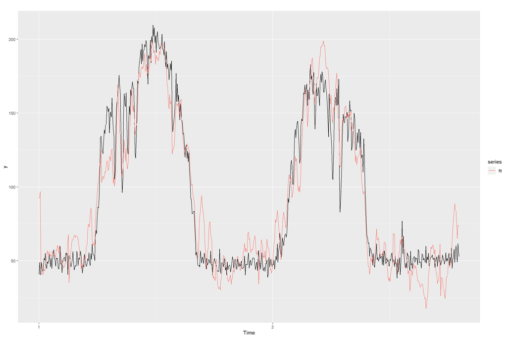

```r
# have to create a time series demand object
y <- ts(train$avg_demand_mgd, frequency = 365)

# remove avg_demand_mgd from train data
train2 <- train %>%
  select(-avg_demand_mgd)

# generate ts model
tslm_mod <- tslm(y ~., data = train2)

fit <- fitted(tslm_mod)
#graph showing actuals vs fitted
autoplot(y) + autolayer(fit)
```

Test ts model against 2022 data

```
## [1] "Train"
```

[output not shown]

```
## [1] "_____________________________________"
```

```
## [1] "2022"
```

```
##          R2         MAE        MAPE        RMSE
##   0.1617259  72.2226216 140.3395962  74.6114530
```

```
## [1] "_____________________________________"
```

```
## [1] "Spring"
```

```
##          R2         MAE        MAPE        RMSE
##   0.2413372 423.3998287 641.5957038 442.8998497
```

```
## [1] "_____________________________________"
```

```
## [1] "Summer"
```

```
##          R2         MAE        MAPE        RMSE
##   0.3713384 402.0580844 249.6090881 409.5030234
```

```
## [1] "_____________________________________"
```

```
## [1] "Fall"
```

```
##          R2         MAE        MAPE        RMSE
##   0.1985291 334.9421879 464.5079730 346.7480518
```

```
## [1] "_____________________________________"
```

```
## [1] "Winter is coming (House Stark)"
```

```
##           R2          MAE         MAPE         RMSE
##   0.03525807 393.18662591 809.70413233 419.66992082
```

> Seems to be way overfit

> The best perofrming model is mod3 using KNN.

# Overfitting Tests on K-Nearest Neighbours Model

## Test

```r
# test
trainpred <- mod3%>%
  predict(test)

compare <- data.frame(actual = test$avg_demand_mgd,
                      predicted = trainpred)

error <- RMSE(trainpred,test$avg_demand_mgd)
ttarg<-test$avg_demand_mgd
print("Test")
```

```
## [1] "Test"
```

```r
mmetric(ttarg,trainpred,metrics_list)
```

```
##         R2        MAE       MAPE       RMSE
##  0.9221763 10.5952196 13.4349206 14.8764333
```

## 10 Fold Cross Validation

```r
df <- Avg4
target <- 11
seedVal <- 6496
metrics_list = c("R2","MAE","MAPE","RMSE")

cv_function <- function(df, target, nFolds, seedVal, metrics_list)
{
# create folds using the assigned values

set.seed(seedVal)
folds = createFolds(df[,target],nFolds)

# The lapply loop

cv_results <- lapply(folds, function(x)
{
# data preparation:

  test_target <- df[x,target]
  test_input <- df[x,-target]

  train_target <- df[-x,target]
  train_input <- df[-x,-target]


   model <- mod3
  pred <- predict(model, test_input)
  return(mmetric(test_target,pred,metrics_list))
})

cv_results_m <- as.matrix(as.data.frame(cv_results))
cv_mean<- as.matrix(rowMeans(cv_results_m))
cv_sd <- as.matrix(rowSds(cv_results_m))
colnames(cv_mean) <- "Mean"
colnames(cv_sd) <- "Sd"
cv_all <- cbind(cv_results_m, cv_mean, cv_sd)
kable(t(cv_all),digits=2)
}
```

```r
cv_function(Avg4, target, 10, seedVal, metrics_list)
```

|  | R2 | MAE | MAPE | RMSE |
| --- | --- | --- | --- | --- |
| Fold01 | 0.98 | 4.05 | 4.73 | 7.31 |
| Fold02 | 0.99 | 3.24 | 4.58 | 4.93 |
| Fold03 | 0.97 | 4.96 | 5.17 | 9.59 |
| Fold04 | 0.98 | 4.18 | 5.78 | 6.55 |
| Fold05 | 0.99 | 4.48 | 6.28 | 7.04 |
| Fold06 | 0.99 | 4.19 | 5.54 | 6.26 |
| Fold07 | 0.97 | 5.44 | 6.08 | 10.00 |
| Fold08 | 0.97 | 4.07 | 4.81 | 8.05 |
| Fold09 | 0.99 | 3.71 | 4.97 | 6.46 |
| Fold10 | 0.99 | 3.61 | 4.27 | 6.04 |
| Mean | 0.98 | 4.19 | 5.22 | 7.22 |
| Sd | 0.01 | 0.64 | 0.67 | 1.59 |

```r
df <- Avg4_W
target <- 11
seedVal <- 6496
metrics_list = c("R2","MAE","MAPE","RMSE")
nFolds = 3

cv_function <- function(df, target, nFolds, seedVal, metrics_list)
{
# create folds using the assigned values

set.seed(seedVal)
folds = createFolds(df[,target],nFolds)

# The lapply loop

cv_results <- lapply(folds, function(x)
{
# data preparation:

  test_target <- df[x,target]
  test_input <- df[x,-target]

  train_target <- df[-x,target]
  train_input <- df[-x,-target]


   model <- mod3
  pred <- predict(model, test_input)
  return(mmetric(test_target,pred,metrics_list))
})

cv_results_m <- as.matrix(as.data.frame(cv_results))
cv_mean<- as.matrix(rowMeans(cv_results_m))
cv_sd <- as.matrix(rowSds(cv_results_m))
colnames(cv_mean) <- "Mean"
colnames(cv_sd) <- "Sd"
cv_all <- cbind(cv_results_m, cv_mean, cv_sd)
kable(t(cv_all),digits=2)
}
```

```r
cv_function(Avg4, target, nFolds, seedVal, metrics_list)
```

|  | R2 | MAE | MAPE | RMSE |
| --- | --- | --- | --- | --- |
| Fold1 | 0.98 | 4.30 | 5.39 | 7.49 |
| Fold2 | 0.98 | 4.06 | 5.01 | 7.24 |
| Fold3 | 0.98 | 4.23 | 5.26 | 7.43 |
| Mean | 0.98 | 4.19 | 5.22 | 7.39 |
| Sd | 0.00 | 0.12 | 0.19 | 0.13 |